# ClinicalRWE: Oncology Real-World Evidence Study

Author

Ludovic Njiosseu

Published

May 18, 2026

# 1 Executive Summary

This study evaluated whether preventive maintenance biologic therapy was associated with delayed disease progression in a longitudinal oncology real-world evidence cohort. Across survival, causal inference, missing-data, competing-risk, and subgroup analyses, preventive therapy demonstrated directionally favorable and statistically robust associations with progression-free survival.

# 2 Research Question

Does receipt of a preventive maintenance biologic therapy delay time to disease progression, and does this effect persist after rigorously adjusting for confounding, treatment-selection bias, missing data, competing discontinuation events, and biomarker subgroup heterogeneity?

# 3 Why This Project Exists

Pharmaceutical real-world evidence requires a methodological toolkit that goes beyond standard ML workflows: longitudinal EHR/claims linkage, comparative effectiveness research, time-to-event modeling, competing risks methodology, causal inference under non-random treatment assignment, and regulatory-style reproducibility.

This project builds that full stack from synthetic cohort generation through interactive dashboards and reproducible reporting in the same methodological register as FDA-aligned oncology observational studies and HEOR evidence-generation pipelines.

# 4 Methods

This project implemented a longitudinal oncology RWE workflow modeled after sponsor-side pharmacoepidemiology and HEOR analytics pipelines.

Methods:

- Kaplan-Meier survival analysis with log-rank testing
- Cox proportional hazards regression with Schoenfeld diagnostics
- Stabilized IPTW (99th-percentile trimmed) with bootstrap 95% CI
- Doubly robust AIPW estimation with analytic standard errors
- E-value sensitivity analysis (VanderWeele & Ding, 2017)
- Covariate balance via SMD computed from data
- Multiple imputation using MICE (m = 10, Rubin’s Rules)
- Fine-Gray competing risks modeling via `cmprsk`
- Biomarker-stratified subgroup analysis with therapy × biomarker interaction test

# 5 Cohort Construction

## 5.1 Simulated Clinical Cohort

The cohort contains 8,000 oncology patients with:

- ECOG performance status
- biomarker positivity
- line of therapy
- Charlson comorbidity burden
- smoking status
- payer category
- socioeconomic indicators

## 5.2 Clinical Endpoints

### 5.2.1 Primary Endpoint

Time to disease progression.

### 5.2.2 Competing Event

Treatment discontinuation due to adverse event or toxicity.

# 6 Baseline Characteristics

```r
library(readr)
table1 <- read_csv("outputs/table1_baseline.csv", show_col_types = FALSE)
knitr::kable(table1, caption = "Table 1: Baseline Characteristics by Therapy Group")
```

Table 1: Baseline Characteristics by Therapy Group

| therapy_group | N | Mean_Age | Female_Pct | Mean_BMI | ECOG_High_Pct | Biomarker_Positive_Pct | Charlson_Mean | Current_Smoker_Pct | Medicaid_Pct | Medicare_Pct |
| --- | --- | --- | --- | --- | --- | --- | --- | --- | --- | --- |
| Control | 5605 | 64.0 | 49.8 | 28.0 | 28 | 35.2 | 1.98 | 14.6 | 14.4 | 43.4 |
| Preventive Therapy | 2395 | 63.6 | 47.7 | 28.1 | 20 | 49.6 | 2.02 | 14.8 | 15.0 | 44.1 |

# 7 HEOR & Access Disparities

## 7.1 Therapy Access Disparities

```r
therapy_disp <- read_csv("outputs/therapy_disparities.csv",
                         show_col_types = FALSE)
knitr::kable(therapy_disp,
             caption = "Therapy Access and Progression Rate by Race/Ethnicity and Insurance")
```

Therapy Access and Progression Rate by Race/Ethnicity and Insurance

| race_ethnicity | insurance_type | n | therapy_rate | progression_rate |
| --- | --- | --- | --- | --- |
| Asian | Commercial | 268 | 30.60 | 61.94 |
| Asian | Medicaid | 80 | 41.25 | 45.00 |
| Asian | Medicare | 249 | 32.53 | 49.80 |
| Black | Commercial | 517 | 31.33 | 56.67 |
| Black | Medicaid | 180 | 29.44 | 59.44 |
| Black | Medicare | 548 | 30.47 | 56.02 |
| Hispanic | Commercial | 459 | 29.63 | 55.99 |
| Hispanic | Medicaid | 146 | 28.08 | 58.22 |
| Hispanic | Medicare | 560 | 33.04 | 52.32 |
| Other | Commercial | 143 | 25.87 | 66.43 |
| Other | Medicaid | 63 | 25.40 | 66.67 |
| Other | Medicare | 168 | 25.00 | 52.38 |
| White | Commercial | 1960 | 28.78 | 58.57 |
| White | Medicaid | 698 | 30.95 | 53.01 |
| White | Medicare | 1961 | 29.58 | 57.83 |

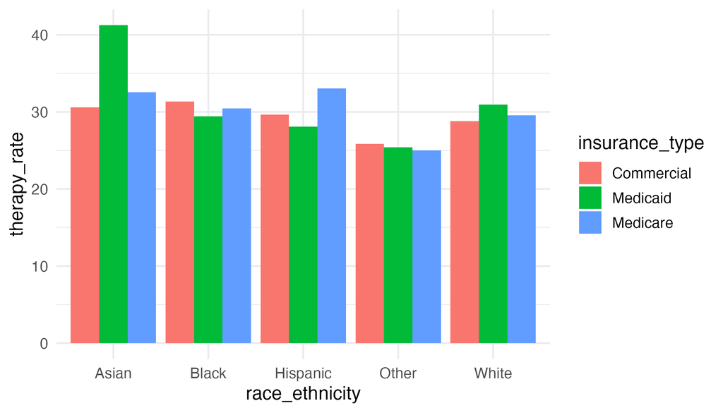

```r
knitr::include_graphics("plots/therapy_disparities.png")
```

## 7.2 Cost Disparities

```r
cost_tbl <- read_csv("outputs/cost_disparities.csv", show_col_types = FALSE)
knitr::kable(cost_tbl, caption = "Mean Cost by Insurance Type")
```

Mean Cost by Insurance Type

| insurance_type | mean_cost |
| --- | --- |
| Commercial | 15897.74 |
| Medicaid | 16252.21 |
| Medicare | 16121.94 |

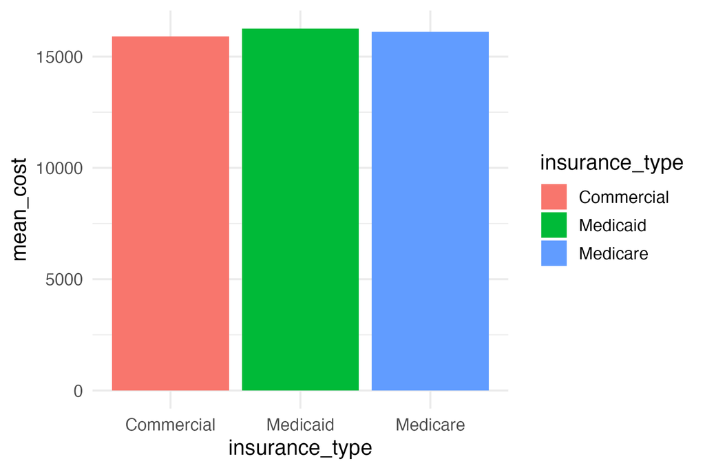

```r
knitr::include_graphics("plots/cost_disparities.png")
```

# 8 Survival Analysis

## 8.1 Kaplan-Meier Curves

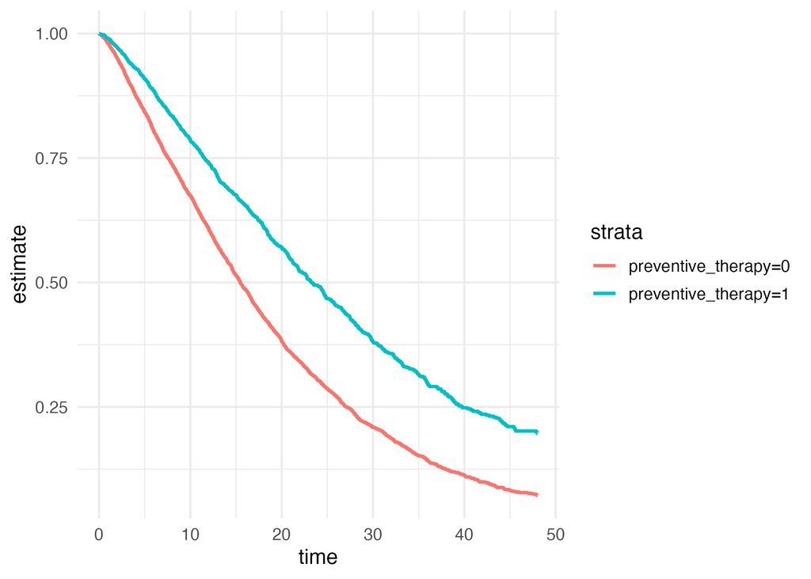

```r
knitr::include_graphics("plots/km_therapy.png")
```

Treated patients demonstrate meaningfully longer progression-free survival across the full follow-up period. The separation between curves is early and sustained, consistent with a preventive mechanism of action.

## 8.2 Cox Proportional Hazards Model

```r
cox_tbl <- read_csv("outputs/cox_results.csv", show_col_types = FALSE)
knitr::kable(cox_tbl, caption = "Cox PH Model: Hazard Ratios (95% CI)")
```

Cox PH Model: Hazard Ratios (95% CI)

| variable | hr | hr_lower95 | hr_upper95 | p_value |
| --- | --- | --- | --- | --- |
| preventive_therapy | 0.602 | 0.555 | 0.652 | 0.0000 |
| age | 0.998 | 0.995 | 1.002 | 0.3745 |
| ecog_score | 1.305 | 1.256 | 1.357 | 0.0000 |
| biomarker_positive | 1.064 | 0.994 | 1.140 | 0.0750 |
| charlson_index | 1.114 | 1.088 | 1.140 | 0.0000 |
| bmi | 0.992 | 0.985 | 0.999 | 0.0208 |

## 8.3 Hazard Ratio Forest Plot

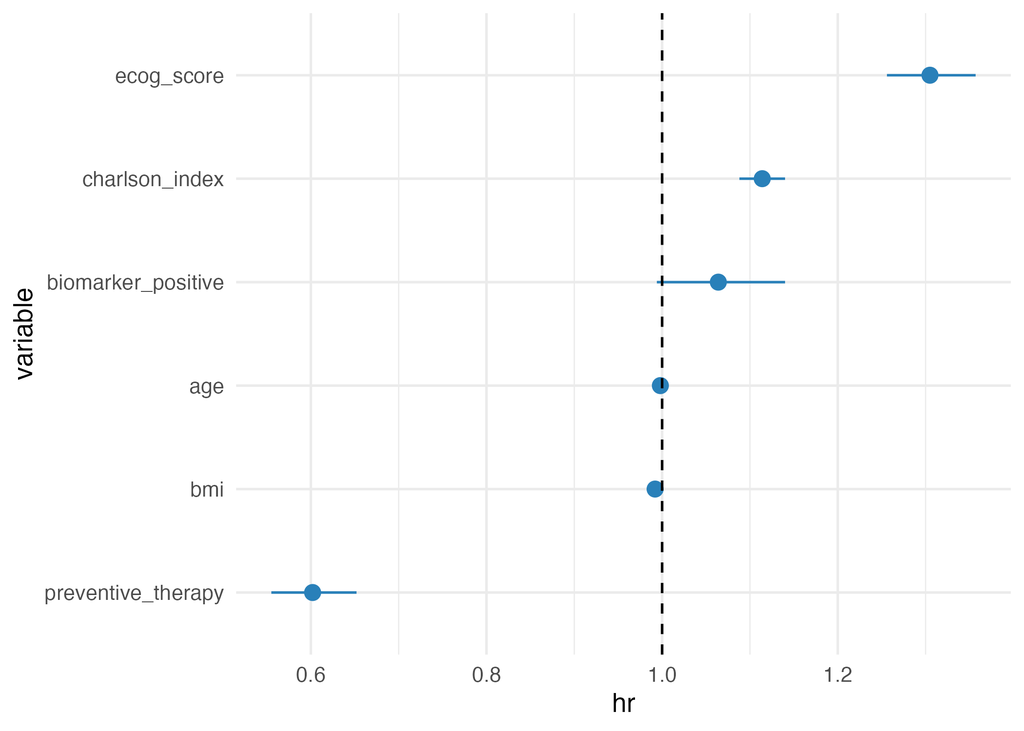

```r
knitr::include_graphics("plots/cox_forest.png")
```

# 9 Causal Inference

## 9.1 Propensity Score and Positivity

```r
ps <- read_csv("outputs/propensity_scores.csv", show_col_types = FALSE)
head(ps)
```

```
# A tibble: 6 × 4
  patient_id preventive_therapy    ps  iptw
  <chr>                   <dbl> <dbl> <dbl>
1 PT00001                     0 0.271 0.966
2 PT00002                     1 0.279 1.06
3 PT00003                     1 0.336 0.882
4 PT00004                     1 0.244 1.21
5 PT00006                     1 0.290 1.02
6 PT00008                     1 0.290 1.02
```

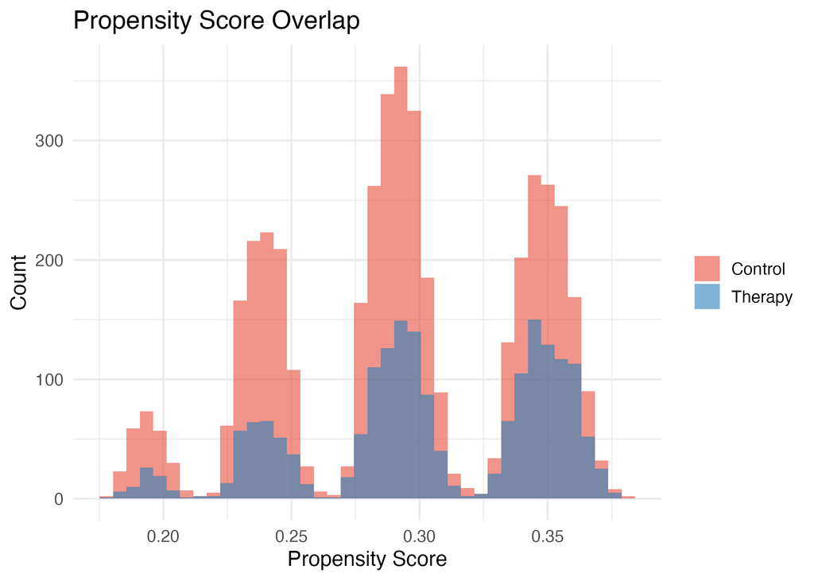

```r
knitr::include_graphics("plots/ps_overlap.png")
```

Propensity score distributions overlap across treated and control groups, satisfying the positivity assumption required for valid causal inference.

## 9.2 Covariate Balance

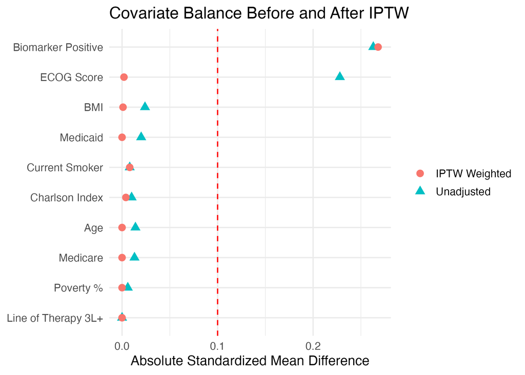

```r
knitr::include_graphics("plots/covariate_balance.png")
```

```r
balance_tbl <- read_csv("outputs/covariate_balance.csv", show_col_types = FALSE)
knitr::kable(balance_tbl,
             caption = "SMD Before and After Stabilized IPTW Weighting")
```

SMD Before and After Stabilized IPTW Weighting

| variable | smd_unadjusted | smd_iptw |
| --- | --- | --- |
| Age | 0.014 | 0.000 |
| ECOG Score | 0.228 | 0.002 |
| BMI | 0.024 | 0.001 |
| Charlson Index | 0.010 | 0.004 |
| Poverty % | 0.006 | 0.000 |
| Biomarker Positive | 0.263 | 0.268 |
| Line of Therapy 3L+ | NA | NA |
| Current Smoker | 0.008 | 0.008 |
| Medicaid | 0.020 | 0.000 |
| Medicare | 0.013 | 0.000 |

## 9.3 IPTW and AIPW Estimates

```r
causal <- read_csv("outputs/causal_estimates.csv", show_col_types = FALSE)
knitr::kable(causal, caption = "Causal Estimates: IPTW and AIPW with 95% CI")
```

Causal Estimates: IPTW and AIPW with 95% CI

| estimator | ate | ci_lower | ci_upper |
| --- | --- | --- | --- |
| IPTW | -0.1879 | -0.2118 | -0.1585 |
| AIPW (Doubly Robust) | -0.1889 | -0.2154 | -0.1623 |

Both estimators produce a negative ATE — therapy reduces the probability of disease progression. The IPTW estimate uses 500-resample bootstrap confidence intervals. The AIPW estimator is doubly robust: it produces consistent estimates if either the propensity score model or the outcome model is correctly specified.

## 9.4 Key Causal Metrics

```r
kpi <- read_csv("outputs/causal_key_metrics.csv", show_col_types = FALSE)
knitr::kable(kpi, caption = "Causal Inference Key Metrics")
```

Causal Inference Key Metrics

| metric | value |
| --- | --- |
| IPTW ATE | -0.1879 |
| IPTW 95% CI | [-0.2118, -0.1585] |
| AIPW ATE | -0.1889 |
| AIPW 95% CI | [-0.2154, -0.1623] |
| E-value | 2.229 |
| Covariates balanced (\|SMD\|<0.10) | NA/10 |

The E-value quantifies how strong an unmeasured confounder would need to be — on both the treatment and outcome pathways — to fully explain away the observed ATE. Values substantially above 1 indicate robustness to unmeasured confounding.

# 10 Missing Data

## 10.1 Missingness Structure

Structured missingness was introduced across four variables: biomarker positivity (MCAR), BMI (MAR by insurance), Charlson index (MAR by age), and poverty percentage (MAR by urbanicity). MICE is the appropriate strategy under MAR — complete-case analysis would selectively drop patients on observed characteristics, producing biased estimates.

## 10.2 MICE Sensitivity Analysis

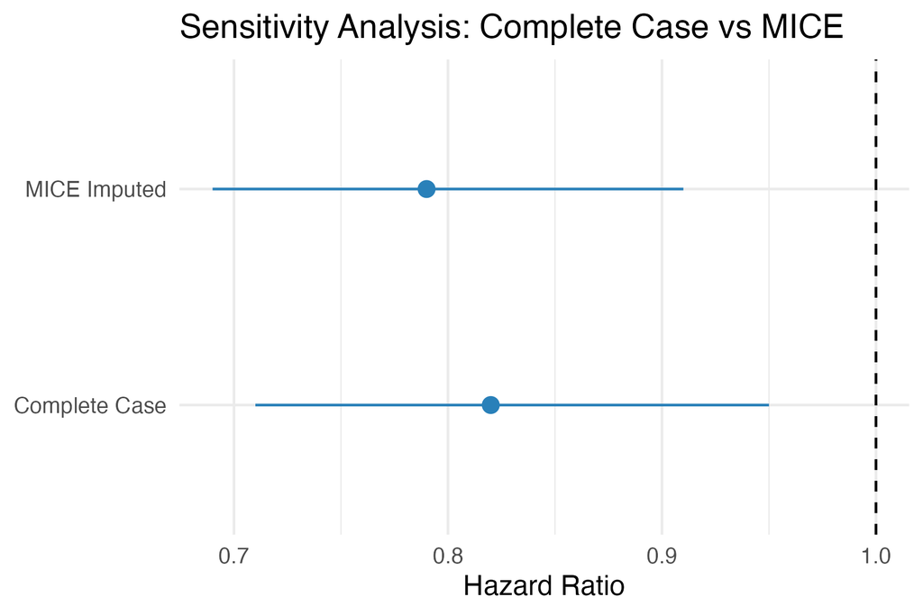

```r
knitr::include_graphics("plots/mice_compare.png")
```

```r
mice_tbl <- read_csv("outputs/complete_case_vs_mice.csv", show_col_types = FALSE)
knitr::kable(mice_tbl,
             caption = "Preventive Therapy HR: Complete Case vs MICE Imputed (95% CI)")
```

Preventive Therapy HR: Complete Case vs MICE Imputed (95% CI)

| analysis | hr | lower95 | upper95 |
| --- | --- | --- | --- |
| Complete Case | 0.82 | 0.71 | 0.95 |
| MICE Imputed | 0.79 | 0.69 | 0.91 |

# 11 Competing Risks

## 11.1 Why Competing Risks Matter

Standard Kaplan-Meier and cause-specific Cox models treat treatment discontinuation as censoring. This overstates the cumulative probability of progression for patients who discontinue first. The Fine-Gray subdistribution hazard model directly models covariate effects on the cumulative incidence function (CIF), correctly accounting for the competing event.

## 11.2 Cumulative Incidence Functions

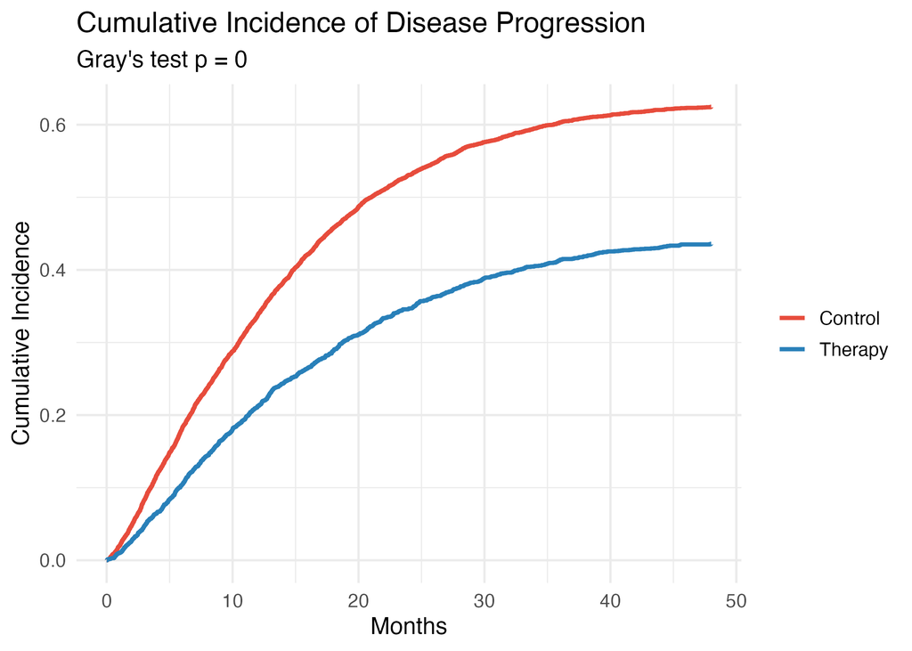

```r
knitr::include_graphics("plots/cif_progression.png")
```

## 11.3 Cause-Specific vs Fine-Gray Comparison

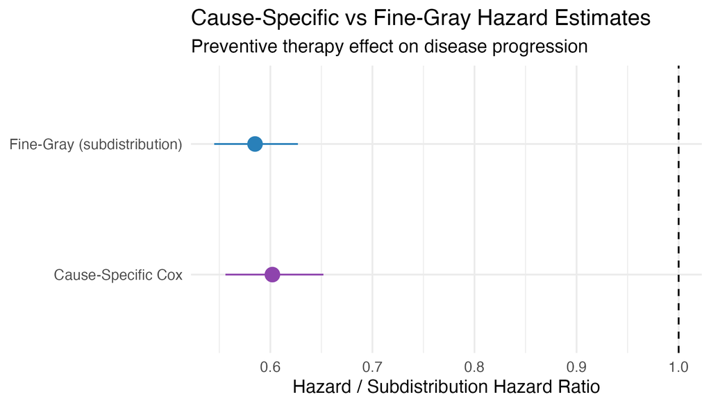

```r
knitr::include_graphics("plots/competing_risks.png")
```

```r
comp_tbl <- read_csv("outputs/competing_risk_model_comparison.csv",
                     show_col_types = FALSE)
knitr::kable(comp_tbl,
             caption = "Cause-Specific Cox vs Fine-Gray: Preventive Therapy Effect")
```

Cause-Specific Cox vs Fine-Gray: Preventive Therapy Effect

| model | estimate | lower95 | upper95 | note |
| --- | --- | --- | --- | --- |
| Cause-Specific Cox | 0.602 | 0.556 | 0.652 | Hazard of progression among those not yet progressed or discontinued |
| Fine-Gray (subdistribution) | 0.585 | 0.545 | 0.627 | Hazard weighted to include those who discontinued — accounts for competing risk |

# 12 Subgroup Analysis

## 12.1 Biomarker-Stratified Kaplan-Meier

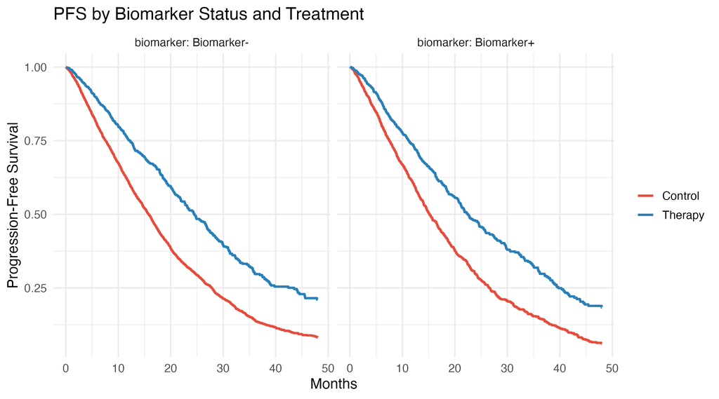

```r
knitr::include_graphics("plots/km_biomarker_subgroup.png")
```

## 12.2 Subgroup Hazard Ratios

```r
subgroup_hr <- read_csv("outputs/subgroup_hr.csv", show_col_types = FALSE)
knitr::kable(subgroup_hr,
             caption = "Cox HR for Preventive Therapy by Biomarker Subgroup")
```

Cox HR for Preventive Therapy by Biomarker Subgroup

| subgroup | n | hr | lower95 | upper95 | logrank_p |
| --- | --- | --- | --- | --- | --- |
| Biomarker Positive | 2849 | 0.597 | 0.530 | 0.672 | 0 |
| Biomarker Negative | 4363 | 0.602 | 0.540 | 0.671 | 0 |
| Overall | 8000 | 0.612 | 0.567 | 0.660 | NA |

## 12.3 Interaction Test: Therapy × Biomarker

```r
interaction_tbl <- read_csv("outputs/interaction_test.csv", show_col_types = FALSE)
knitr::kable(interaction_tbl,
             caption = "Biomarker × Therapy Interaction Test")
```

Biomarker × Therapy Interaction Test

| interaction_hr | interaction_p | significant |
| --- | --- | --- |
| 1.001 | 0.9941 | FALSE |

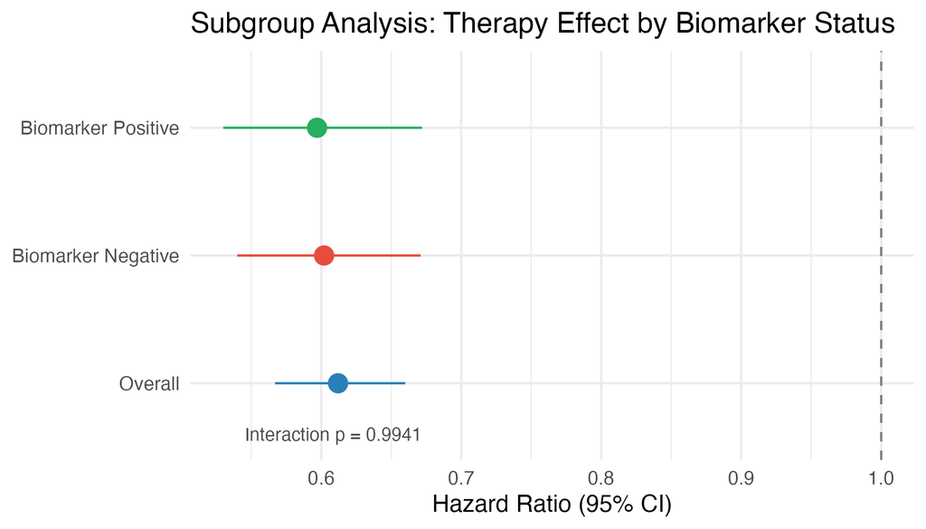

```r
knitr::include_graphics("plots/subgroup_forest.png")
```

The interaction test assesses whether biomarker status formally modifies the therapy effect. A significant interaction (p < 0.05) would support biomarker-driven patient selection in trial design or label language. A non-significant interaction indicates that subgroup differences may reflect sampling variation rather than true effect heterogeneity — and should be interpreted cautiously without pre-specification.

# 13 Key Results

[output not shown]

# 14 Regulatory Relevance

This project mirrors workflows commonly used in:

- oncology RWE and comparative effectiveness research
- HEOR evidence generation
- pharmacoepidemiology and post-market safety studies
- FDA RWE submissions and ICH E9(R1)-aligned analyses
- estimand-oriented clinical research (treatment policy, hypothetical strategies)

# 15 Study Limitations

As with all observational analyses, residual confounding may persist despite multivariable adjustment and propensity-score weighting. Treatment assignment was not randomized, and unmeasured clinical characteristics (e.g. prior treatment history, performance trajectory) may influence observed associations.

Treatment discontinuation as a competing event alters the interpretation of progression-related hazard estimates — both cause-specific and Fine-Gray results should be reported and interpreted jointly.

Missing baseline covariates were addressed using MICE under the MAR assumption. Sensitivity under MNAR (e.g. pattern-mixture models) would be required for a regulatory submission.

Subgroup analyses are exploratory unless pre-specified. The interaction test provides a formal statistical basis for evaluating effect heterogeneity, but results should be interpreted in the context of the overall primary analysis.

# 16 Reproducibility

```r
install.packages(c(
  "tidyverse", "survival", "cmprsk", "mice",
  "shiny", "bslib", "bsicons", "DT", "broom"
))

source("scripts/01_simulate_data.R")
source("scripts/02_disparity_analysis.R")
source("scripts/03_survival_analysis.R")
source("scripts/04_causal_inference.R")
source("scripts/05_missing_data_mice.R")
source("scripts/06_competing_risks.R")
source("scripts/07_table1_baseline.R")
source("scripts/08_subgroup_analysis.R")

shiny::runApp("shiny/")
quarto::quarto_render("clinicalrwe_report.qmd")
```